# Hyperparameter Optimization Example

### Author and Date:

- Christian Michelsen (Niels Bohr Institute)
- 15-05-2019 (latest update)
- Interactive Jupyter Notebook Presentation about Hyperparameter Optimization (HPO)
1. Naive, manual approach
2. Grid search
3. Random search
4. Bayesian optimization
5. "Full" scan over parameter space
6. Other Examples
- **[HTRU2 Pulsar dataset](https://archive.ics.uci.edu/ml/datasets/HTRU2)**
- Focus on the understanding of HPO, not the actual code

### Nomenclature

- Machine Learning Model: $\mathcal{A}$
- $N$ hyperparameters
- Domain: $\Lambda_n$
- Hyperparameter configuration space: $\mathbf{\Lambda}=\Lambda_1 \times \Lambda_2 \times \dots \times \Lambda_N $
- Vector of hyperparameters: $\mathbf{\lambda} \in \mathbf{\Lambda}$
- Specific ML model: $\mathcal{A}_\mathbf{\lambda}$

### Domain of hyperparameters:

1. real
2. integer
3. binary
4. categorical

### Goal:

Given a dataset $\mathcal{D}$, find $\mathbf{\lambda}^{*}$ where:

$$ \mathbf{\lambda}^{*} = \mathop{\mathrm{argmin}}_{\mathbf{\lambda} \in \mathbf{\Lambda}} \mathbb{E}_{D_\mathrm{test} \thicksim \mathcal{D}} \, \left[ \mathbf{V}\left(\mathcal{L}, \mathcal{A}_\mathbf{\lambda}, D_\mathrm{test}\right) \right] $$

In practice we have to approximate the expectation above.

First, we import the modules we want to use:

```python
import numpy as np
from sklearn.tree import DecisionTreeClassifier, export_graphviz
from sklearn import tree
from sklearn.datasets import load_iris, load_wine
from sklearn.metrics import accuracy_score
from IPython.display import SVG
from graphviz import Source
from IPython.display import display
from ipywidgets import interactive
import pandas as pd
from sklearn.model_selection import train_test_split
from sklearn.model_selection import GridSearchCV
import seaborn as sns
from sklearn.model_selection import RandomizedSearchCV
from scipy.stats import randint, poisson
import numpy as np
import matplotlib.pyplot as plt
from tqdm import tqdm
```

We read in the data:

```python
df = pd.read_csv('Pulsar_data.csv')

df.head(10)
```

|  | Mean_SNR | STD_SNR | Kurtosis_SNR | Skewness_SNR | Class |
| --- | --- | --- | --- | --- | --- |
| 0 | 27.555184 | 61.719016 | 2.208808 | 3.662680 | 1 |
| 1 | 1.358696 | 13.079034 | 13.312141 | 212.597029 | 1 |
| 2 | 73.112876 | 62.070220 | 1.268206 | 1.082920 | 1 |
| 3 | 146.568562 | 82.394624 | -0.274902 | -1.121848 | 1 |
| 4 | 6.071070 | 29.760400 | 5.318767 | 28.698048 | 1 |
| 5 | 32.919732 | 65.094197 | 1.605538 | 0.871364 | 1 |
| 6 | 34.101171 | 62.577395 | 1.890020 | 2.572133 | 1 |
| 7 | 50.107860 | 66.321825 | 1.456423 | 1.335182 | 1 |
| 8 | 176.119565 | 59.737720 | -1.785377 | 2.940913 | 1 |
| 9 | 183.622910 | 79.932815 | -1.326647 | 0.346712 | 1 |

And load the actual dataset:

```python
X = df.drop(columns='Class')
y = df['Class']
feature_names = df.columns.tolist()[:-1]

print(X.shape)

X_train, X_test, y_train, y_test = train_test_split(X,
                                                    y,
                                                    test_size=0.20,
                                                    random_state=42)
X_train.head(10)
```

```
(3278, 4)
```

|  | Mean_SNR | STD_SNR | Kurtosis_SNR | Skewness_SNR |
| --- | --- | --- | --- | --- |
| 233 | 159.849498 | 76.740010 | -0.575016 | -0.941293 |
| 831 | 4.243311 | 26.746490 | 7.110978 | 52.701218 |
| 2658 | 1.015050 | 10.449662 | 15.593479 | 316.011541 |
| 2495 | 2.235786 | 19.071848 | 9.659137 | 99.294390 |
| 2603 | 2.266722 | 15.512103 | 9.062942 | 99.652157 |
| 111 | 121.404682 | 47.965569 | 0.663053 | 1.203139 |
| 1370 | 35.209866 | 60.573157 | 1.635995 | 1.609377 |
| 1124 | 199.577759 | 58.656643 | -1.862320 | 2.391870 |
| 2170 | 0.663043 | 8.571517 | 23.415092 | 655.614875 |
| 2177 | 3.112876 | 16.855717 | 8.301954 | 90.378150 |

And check out the y values:

```python
y_train.head(10)
```

```
233     1
831     1
2658    0
2495    0
2603    0
111     1
1370    1
1124    1
2170    0
2177    0
Name: Class, dtype: int64
```

```python
y_train.value_counts()
```

```
0    1319
1    1303
Name: Class, dtype: int64
```

## Part A: Naïve Approach

- Manual configuration
- *"[Babysitting is also known as Trial & Error or Grad Student Descent in the academic field](https://blog.floydhub.com/guide-to-hyperparameters-search-for-deep-learning-models/)"*

```python
def fit_and_grapth_estimator(estimator):

    estimator.fit(X_train, y_train)

    accuracy = accuracy_score(y_train, estimator.predict(X_train))
    print(f'Training Accuracy: {accuracy:.4f}')

    class_names = [str(i) for i in range(y_train.nunique())]
    graph = Source(tree.export_graphviz(estimator,
                                        out_file=None,
                                        feature_names=feature_names,
                                        class_names=class_names,
                                        filled = True))
    display(SVG(graph.pipe(format='svg')))
    return estimator


def plot_tree(max_depth=1, min_samples_leaf=1):

    estimator = DecisionTreeClassifier(random_state=42,
                                       max_depth=max_depth,
                                       min_samples_leaf=min_samples_leaf)

    return fit_and_grapth_estimator(estimator)

display(interactive(plot_tree,
                    max_depth=(1, 10, 1),
                    min_samples_leaf=(1, 100, 1)))
```

**(Test this interactively in notebook)**

And test this configuration out on the test data:

```python
clf_manual = DecisionTreeClassifier(random_state=42,
                                    max_depth=10,
                                    min_samples_leaf=5)

clf_manual.fit(X_train, y_train)
accuracy_manual = accuracy_score(y_test, clf_manual.predict(X_test))
print(f'Accuracy Manual: {accuracy_manual:.4f}')
```

```
Accuracy Manual: 0.8201
```

## Part B: Grid Search

Grid Search:

- *full factorial design*
- Cartesian product
- Curse of dimensionality (grows exponentially)

[figure not shown]

**[Grid Search](https://scikit-learn.org/stable/modules/generated/sklearn.model_selection.GridSearchCV.html#sklearn.model_selection.GridSearchCV)** with Scikit Learn:

```python
parameters_GridSearch = {'max_depth':[1, 10, 100],
                         'min_samples_leaf':[1, 10, 100],
                        }
```

```python
clf_DecisionTree = DecisionTreeClassifier(random_state=42)
```

```python
GridSearch = GridSearchCV(clf_DecisionTree,
                          parameters_GridSearch,
                          cv=5,
                          return_train_score=True,
                          refit=True,
                          iid=False)
```

```python
GridSearch.fit(X_train, y_train);
```

```python
GridSearch_results = pd.DataFrame(GridSearch.cv_results_)
```

```python
print("Grid Search: \tBest parameters: ", GridSearch.best_params_, f", Best scores: {GridSearch.best_score_:.4f}\n")
```

```
Grid Search: 	Best parameters:  {'max_depth': 1, 'min_samples_leaf': 1} , Best scores: 0.8551
```

```python
GridSearch_results
```

|  | mean_fit_time | std_fit_time | mean_score_time | std_score_time | param_max_depth | param_min_samples_leaf | params | split0_test_score | split1_test_score | split2_test_score | ... | mean_test_score | std_test_score | rank_test_score | split0_train_score | split1_train_score | split2_train_score | split3_train_score | split4_train_score | mean_train_score | std_train_score |
| --- | --- | --- | --- | --- | --- | --- | --- | --- | --- | --- | --- | --- | --- | --- | --- | --- | --- | --- | --- | --- | --- |
| 0 | 0.003473 | 0.000367 | 0.001180 | 0.000063 | 1 | 1 | {'max_depth': 1, 'min_samples_leaf': 1} | 0.849524 | 0.862857 | 0.862857 | ... | 0.855063 | 0.009268 | 1 | 0.862184 | 0.858369 | 0.858846 | 0.859390 | 0.860410 | 0.859840 | 0.001355 |
| 1 | 0.003123 | 0.000253 | 0.001321 | 0.000207 | 1 | 10 | {'max_depth': 1, 'min_samples_leaf': 10} | 0.849524 | 0.862857 | 0.862857 | ... | 0.855063 | 0.009268 | 1 | 0.862184 | 0.858369 | 0.858846 | 0.859390 | 0.860410 | 0.859840 | 0.001355 |
| 2 | 0.002749 | 0.000144 | 0.001059 | 0.000107 | 1 | 100 | {'max_depth': 1, 'min_samples_leaf': 100} | 0.849524 | 0.862857 | 0.862857 | ... | 0.855063 | 0.009268 | 1 | 0.862184 | 0.858369 | 0.858846 | 0.859390 | 0.860410 | 0.859840 | 0.001355 |
| 3 | 0.007866 | 0.000687 | 0.001200 | 0.000156 | 10 | 1 | {'max_depth': 10, 'min_samples_leaf': 1} | 0.847619 | 0.822857 | 0.859048 | ... | 0.841720 | 0.012099 | 8 | 0.956128 | 0.948021 | 0.954220 | 0.962345 | 0.957122 | 0.955567 | 0.004635 |
| 4 | 0.006552 | 0.000206 | 0.000956 | 0.000059 | 10 | 10 | {'max_depth': 10, 'min_samples_leaf': 10} | 0.845714 | 0.847619 | 0.853333 | ... | 0.846291 | 0.008921 | 6 | 0.896042 | 0.898903 | 0.898426 | 0.893232 | 0.895665 | 0.896454 | 0.002053 |
| 5 | 0.004531 | 0.000169 | 0.001063 | 0.000069 | 10 | 100 | {'max_depth': 10, 'min_samples_leaf': 100} | 0.849524 | 0.862857 | 0.862857 | ... | 0.855063 | 0.009268 | 1 | 0.862184 | 0.858369 | 0.858846 | 0.859390 | 0.860410 | 0.859840 | 0.001355 |
| 6 | 0.007885 | 0.000215 | 0.001032 | 0.000049 | 100 | 1 | {'max_depth': 100, 'min_samples_leaf': 1} | 0.826667 | 0.796190 | 0.841905 | ... | 0.824184 | 0.015118 | 9 | 1.000000 | 1.000000 | 1.000000 | 1.000000 | 1.000000 | 1.000000 | 0.000000 |
| 7 | 0.006780 | 0.000213 | 0.000984 | 0.000124 | 100 | 10 | {'max_depth': 100, 'min_samples_leaf': 10} | 0.845714 | 0.849524 | 0.855238 | ... | 0.845143 | 0.010045 | 7 | 0.896996 | 0.899857 | 0.898426 | 0.894185 | 0.896617 | 0.897216 | 0.001899 |
| 8 | 0.004509 | 0.000217 | 0.000937 | 0.000069 | 100 | 100 | {'max_depth': 100, 'min_samples_leaf': 100} | 0.849524 | 0.862857 | 0.862857 | ... | 0.855063 | 0.009268 | 1 | 0.862184 | 0.858369 | 0.858846 | 0.859390 | 0.860410 | 0.859840 | 0.001355 |

9 rows × 22 columns

```python
clf_GridSearch = GridSearch.best_estimator_
```

```python
accuracy_GridSearch = accuracy_score(y_test, clf_GridSearch.predict(X_test))
print(f'Accuracy Manual:      {accuracy_manual:.4f}')
print(f'Accuracy Grid Search: {accuracy_GridSearch:.4f}')
```

```
Accuracy Manual:      0.8201
Accuracy Grid Search: 0.8430
```

## Part C: Random Search

- $B$ function evaluations, $N$ hyperparameters, $y$ number of different values:

$$ y_{\mathrm{GS}} = B^{1/N}, \quad y_{\mathrm{RS}} = B $$

[figure not shown]

- *"This failure of grid search is the rule rather than the exception in high dimensional hyper-parameter optimization"* [Bergstra, 2012]
- useful baseline because (almost) no assumptions about the ML algorithm being optimized.

**[Random Search](http://www.jmlr.org/papers/volume13/bergstra12a/bergstra12a.pdf)** with **[Scikit Learn](https://scikit-learn.org/stable/modules/generated/sklearn.model_selection.RandomizedSearchCV.html#sklearn.model_selection.RandomizedSearchCV)** using **[Scipy Stats](https://docs.scipy.org/doc/scipy/reference/stats.html)** as PDFs for the parameters:

```python
# specify parameters and distributions to sample from
parameters_RandomSearch = {'max_depth': poisson(25),
                           'min_samples_leaf': randint(1, 100)}
```

```python
# run randomized search
n_iter_search = 9
RandomSearch = RandomizedSearchCV(clf_DecisionTree,
                                  param_distributions=parameters_RandomSearch,
                                  n_iter=n_iter_search,
                                  cv=5,
                                  iid=True,
                                  return_train_score=True,
                                  random_state=42)
```

```python
# fit the random search instance
RandomSearch.fit(X_train, y_train);
```

```python
RandomSearch_results = pd.DataFrame(RandomSearch.cv_results_)
print("Random Search: \tBest parameters: ", RandomSearch.best_params_, f", Best scores: {RandomSearch.best_score_:.3f}")
```

```
Random Search: 	Best parameters:  {'max_depth': 26, 'min_samples_leaf': 83} , Best scores: 0.855
```

```python
RandomSearch_results.head(10)
```

|  | mean_fit_time | std_fit_time | mean_score_time | std_score_time | param_max_depth | param_min_samples_leaf | params | split0_test_score | split1_test_score | split2_test_score | ... | mean_test_score | std_test_score | rank_test_score | split0_train_score | split1_train_score | split2_train_score | split3_train_score | split4_train_score | mean_train_score | std_train_score |
| --- | --- | --- | --- | --- | --- | --- | --- | --- | --- | --- | --- | --- | --- | --- | --- | --- | --- | --- | --- | --- | --- |
| 0 | 0.005541 | 0.000327 | 0.001136 | 0.000203 | 23 | 72 | {'max_depth': 23, 'min_samples_leaf': 72} | 0.849524 | 0.862857 | 0.862857 | ... | 0.854310 | 0.010586 | 6 | 0.862184 | 0.858369 | 0.858846 | 0.859390 | 0.860410 | 0.859840 | 0.001355 |
| 1 | 0.005265 | 0.000723 | 0.001016 | 0.000124 | 26 | 83 | {'max_depth': 26, 'min_samples_leaf': 83} | 0.849524 | 0.862857 | 0.862857 | ... | 0.855072 | 0.009263 | 1 | 0.862184 | 0.858369 | 0.858846 | 0.859390 | 0.860410 | 0.859840 | 0.001355 |
| 2 | 0.006634 | 0.000433 | 0.001157 | 0.000126 | 17 | 24 | {'max_depth': 17, 'min_samples_leaf': 24} | 0.847619 | 0.860952 | 0.868571 | ... | 0.854310 | 0.012320 | 6 | 0.875536 | 0.879351 | 0.878398 | 0.875596 | 0.881848 | 0.878146 | 0.002389 |
| 3 | 0.004533 | 0.000143 | 0.000931 | 0.000058 | 27 | 88 | {'max_depth': 27, 'min_samples_leaf': 88} | 0.849524 | 0.862857 | 0.862857 | ... | 0.855072 | 0.009263 | 1 | 0.862184 | 0.858369 | 0.858846 | 0.859390 | 0.860410 | 0.859840 | 0.001355 |
| 4 | 0.005221 | 0.000362 | 0.001047 | 0.000137 | 31 | 64 | {'max_depth': 31, 'min_samples_leaf': 64} | 0.849524 | 0.862857 | 0.862857 | ... | 0.855072 | 0.009263 | 1 | 0.862184 | 0.858369 | 0.858846 | 0.859390 | 0.861363 | 0.860030 | 0.001482 |
| 5 | 0.004624 | 0.000195 | 0.000945 | 0.000111 | 27 | 89 | {'max_depth': 27, 'min_samples_leaf': 89} | 0.849524 | 0.862857 | 0.862857 | ... | 0.855072 | 0.009263 | 1 | 0.862184 | 0.858369 | 0.858846 | 0.859390 | 0.860410 | 0.859840 | 0.001355 |
| 6 | 0.005376 | 0.000317 | 0.000942 | 0.000138 | 22 | 42 | {'max_depth': 22, 'min_samples_leaf': 42} | 0.849524 | 0.836190 | 0.857143 | ... | 0.845538 | 0.015713 | 9 | 0.866476 | 0.865999 | 0.862661 | 0.865110 | 0.864221 | 0.864893 | 0.001357 |
| 7 | 0.005001 | 0.000258 | 0.000968 | 0.000070 | 21 | 62 | {'max_depth': 21, 'min_samples_leaf': 62} | 0.849524 | 0.840000 | 0.862857 | ... | 0.850496 | 0.009910 | 8 | 0.862184 | 0.858369 | 0.858846 | 0.859390 | 0.861363 | 0.860030 | 0.001482 |
| 8 | 0.004964 | 0.000198 | 0.000940 | 0.000077 | 20 | 64 | {'max_depth': 20, 'min_samples_leaf': 64} | 0.849524 | 0.862857 | 0.862857 | ... | 0.855072 | 0.009263 | 1 | 0.862184 | 0.858369 | 0.858846 | 0.859390 | 0.861363 | 0.860030 | 0.001482 |

9 rows × 22 columns

```python
clf_RandomSearch = RandomSearch.best_estimator_

accuracy_RandomSearch = accuracy_score(y_test, clf_RandomSearch.predict(X_test))
print(f'Accuracy Manual:        {accuracy_manual:.4f}')
print(f'Accuracy Grid search:   {accuracy_GridSearch:.4f}')
print(f'Accuracy Random Search: {accuracy_RandomSearch:.4f}')
```

```
Accuracy Manual:        0.8201
Accuracy Grid search:   0.8430
Accuracy Random Search: 0.8430
```

## Part D: Bayesian Optimization

- Expensive black box functions $\Rightarrow$ need of smart guesses
1. Probabilistic Surrogate Model (to be fitted)
   - Often Gaussian Processes
2. Acquisition function
   - Exploitation / Exploration
   - Cheap to Computer

*[Brochu, Cora, de Freitas, 2010]*

[figure not shown]

**[Bayesian Optimization](https://arxiv.org/pdf/1012.2599v1.pdf)** with the Python package **BayesianOptimization**:

```python
from bayes_opt import BayesianOptimization
from sklearn.model_selection import cross_val_score

def DecisionTree_CrossValidation(max_depth, min_samples_leaf, data, targets):
    """Decision Tree cross validation.
       Fits a Decision Tree with the given paramaters to the target
       given data, calculated a CV accuracy score and returns the mean.
       The goal is to find combinations of max_depth, min_samples_leaf
       that maximize the accuracy
    """

    estimator = DecisionTreeClassifier(random_state=42,
                                       max_depth=max_depth,
                                       min_samples_leaf=min_samples_leaf)

    cval = cross_val_score(estimator, data, targets, scoring='accuracy', cv=5)

    return cval.mean()
```

```python
def optimize_DecisionTree(data, targets, pars, n_iter=5):
    """Apply Bayesian Optimization to Decision Tree parameters."""

    def crossval_wrapper(max_depth, min_samples_leaf):
        """Wrapper of Decision Tree cross validation.
           Notice how we ensure max_depth, min_samples_leaf
           are casted to integer before we pass them along.
        """
        return DecisionTree_CrossValidation(max_depth=int(max_depth),
                                            min_samples_leaf=int(min_samples_leaf),
                                            data=data,
                                            targets=targets)

    optimizer = BayesianOptimization(f=crossval_wrapper,
                                     pbounds=pars,
                                     random_state=42,
                                     verbose=2)
    optimizer.maximize(init_points=4, n_iter=n_iter)

    return optimizer
```

```python
parameters_BayesianOptimization = {"max_depth": (1, 100),
                                   "min_samples_leaf": (1, 100),
                                  }

BayesianOptimization = optimize_DecisionTree(X_train,
                                             y_train,
                                             parameters_BayesianOptimization,
                                             n_iter=5)
print(BayesianOptimization.max)
```

```
|   iter    |  target   | max_depth | min_sa... |
-------------------------------------------------
|  1        |  0.8551   |  38.08    |  95.12    |
|  2        |  0.849    |  73.47    |  60.27    |
|  3        |  0.8524   |  16.45    |  16.44    |
|  4        |  0.8551   |  6.75     |  86.75    |
|  5        |  0.8551   |  1.161    |  99.55    |
|  6        |  0.8551   |  1.038    |  99.98    |
|  7        |  0.8551   |  1.417    |  99.85    |
|  8        |  0.8551   |  1.171    |  99.52    |
|  9        |  0.8551   |  1.526    |  99.61    |
=================================================
{'target': 0.8550626526908692, 'params': {'max_depth': 38.07947176588889, 'min_samples_leaf': 95.1207163345817}}
```

```python
params = BayesianOptimization.max['params']
```

```python
clf_BO = DecisionTreeClassifier(random_state=42, **params)
clf_BO = clf_BO.fit(X_train, y_train)
```

```python
accuracy_BayesianOptimization = accuracy_score(y_test, clf_BO.predict(X_test))
print(f'Accuracy Manual:                {accuracy_manual:.4f}')
print(f'Accuracy Grid Search:           {accuracy_GridSearch:.4f}')
print(f'Accuracy Random Search:         {accuracy_RandomSearch:.4f}')
print(f'Accuracy Bayesian Optimization: {accuracy_BayesianOptimization:.4f}')
```

```
Accuracy Manual:                0.8201
Accuracy Grid Search:           0.8430
Accuracy Random Search:         0.8430
Accuracy Bayesian Optimization: 0.8430
```

## Part D: Full Scan over Parameter Space

Only possible in low-dimensional space, slow

```python
max_depth_array = np.arange(1, 30)
min_samples_leaf_array = np.arange(2, 31)
Z = np.zeros((len(max_depth_array), len(min_samples_leaf_array)))

for i, max_depth in enumerate(tqdm(max_depth_array)):
    for j, min_samples_leaf in enumerate(min_samples_leaf_array):

        clf = DecisionTreeClassifier(random_state=42,
                                     max_depth=max_depth,
                                     min_samples_leaf=
                                     min_samples_leaf)
        clf.fit(X_train, y_train)
        acc = accuracy_score(y_test, clf.predict(X_test))
        Z[i, j] = acc

# Notice: have to transpose Z to match up with imshow
Z = Z.T
```

Plot the results:

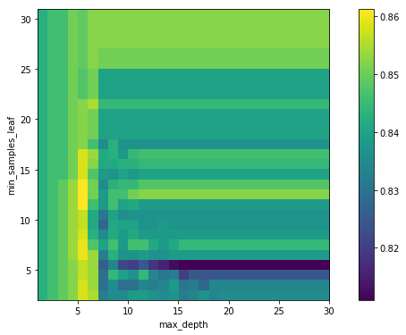

```python
fig, ax = plt.subplots(figsize=(12, 6))

# notice that we are setting the extent and origin keywords
CS = ax.imshow(Z, extent=[1, 30, 2, 31], cmap='viridis', origin='lower')
ax.set(xlabel='max_depth', ylabel='min_samples_leaf')

fig.colorbar(CS);
```

### Sum up:

[figure not shown]

**[Guide To Hyperparameters Search For Deep Learning Models](https://blog.floydhub.com/guide-to-hyperparameters-search-for-deep-learning-models/)**

## Part E: Other Examples

Some of my own examples:

[figure not shown]

- Learning rate

## Questions?

**http://bit.ly/AppliedMachineLearning**